# ISLR - Ch3 - Linear Regression

## Question 10: This question should be answered using the `Carseats` data set.

1. Fit a multiple regression model to predict `Sales` using `Price`, `Urban` and `US`.

```r
df = Carseats
model = lm(data = df, Sales ~ Price + Urban + US)
model
```

```
##
## Call:
## lm(formula = Sales ~ Price + Urban + US, data = df)
##
## Coefficients:
## (Intercept)        Price     UrbanYes        USYes
##    13.04347     -0.05446     -0.02192      1.20057
```

2. Provide an interpretation of each coefficient in the model. Be careful - some of the variables in the model are qualitative!

For each dollar increase in price, sales decrease by $\$54$. If the store is in an urban location, then the sales decrease by $\$21$. If the store is in the US, then the sales increase by $\$1200$.

3. Write out the model in equation form, being careful to handle the qualitative variables properly.
   $$\text{Sales} = 13.04347 - 0.05446 * \text{Price} - 0.02192 * \text{UrbanYes} + 1.20057 * \text{USYes}$$
4. For which of the predictors can you reject the null hypothesis $H_0: \beta_j = 0$?

```r
summary(model)
```

```
##
## Call:
## lm(formula = Sales ~ Price + Urban + US, data = df)
##
## Residuals:
##     Min      1Q  Median      3Q     Max
## -6.9206 -1.6220 -0.0564  1.5786  7.0581
##
## Coefficients:
##              Estimate Std. Error t value Pr(>|t|)
## (Intercept) 13.043469   0.651012  20.036  < 2e-16 ***
## Price       -0.054459   0.005242 -10.389  < 2e-16 ***
## UrbanYes    -0.021916   0.271650  -0.081    0.936
## USYes        1.200573   0.259042   4.635 4.86e-06 ***
## ---
## Signif. codes:  0 '***' 0.001 '**' 0.01 '*' 0.05 '.' 0.1 ' ' 1
##
## Residual standard error: 2.472 on 396 degrees of freedom
## Multiple R-squared:  0.2393, Adjusted R-squared:  0.2335
## F-statistic: 41.52 on 3 and 396 DF,  p-value: < 2.2e-16
```

The null hypothesis can be rejected for the `price` and `US` predictors since the $p$-values are low and so they are statistically significant.

5. On the basis of the response to the previous question, fit a smaller model that only uses the predictors for which there is evidence of association with the outcome.

```r
model2 = lm(data = df, Sales~Price + US)
summary(model2)
```

```
##
## Call:
## lm(formula = Sales ~ Price + US, data = df)
##
## Residuals:
##     Min      1Q  Median      3Q     Max
## -6.9269 -1.6286 -0.0574  1.5766  7.0515
##
## Coefficients:
##             Estimate Std. Error t value Pr(>|t|)
## (Intercept) 13.03079    0.63098  20.652  < 2e-16 ***
## Price       -0.05448    0.00523 -10.416  < 2e-16 ***
## USYes        1.19964    0.25846   4.641 4.71e-06 ***
## ---
## Signif. codes:  0 '***' 0.001 '**' 0.01 '*' 0.05 '.' 0.1 ' ' 1
##
## Residual standard error: 2.469 on 397 degrees of freedom
## Multiple R-squared:  0.2393, Adjusted R-squared:  0.2354
## F-statistic: 62.43 on 2 and 397 DF,  p-value: < 2.2e-16
```

6. How well do the models in (a) and (e) fit the data?

The model in (e) has a slightly lower residual standard error.

7. Using the model from (e), obtain $95\%$ confidence intervals for the coefficients(s).

```r
confint(model2)
```

```
##                   2.5 %      97.5 %
## (Intercept) 11.79032020 14.27126531
## Price       -0.06475984 -0.04419543
## USYes        0.69151957  1.70776632
```

8. Is there evidence of outliers or high leverage observations in the model from (e)?

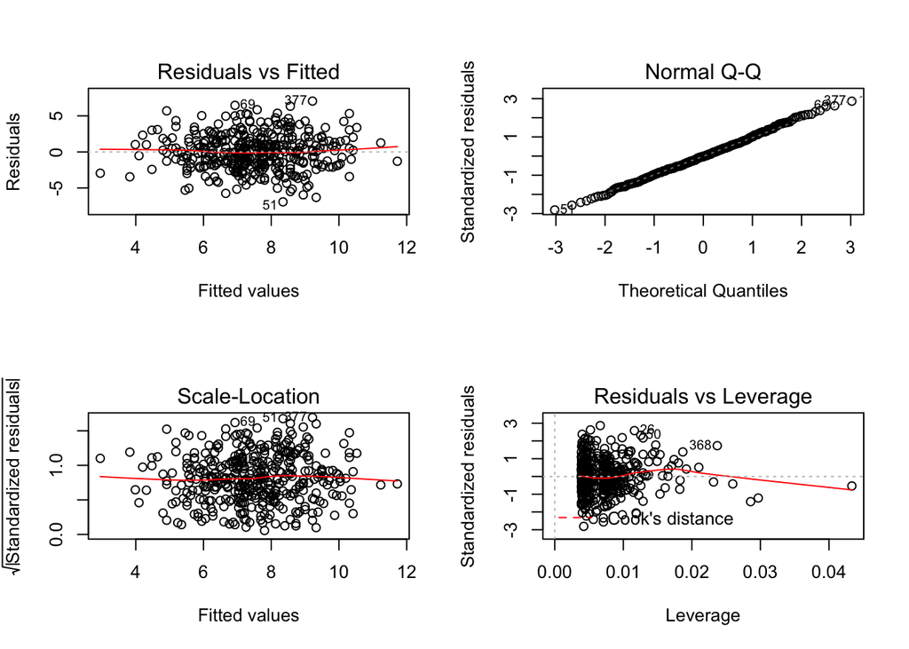

```r
par(mfrow=c(2,2))
plot(model2)
```

The residuals do not show any abnormal activities, thus there are no outliers. There does appear to be one high leverage point.

## Question 11: In this problem, you will investigate the $t$-statistic for the null hypotheis $H_0: \beta = 0$ in simple linear regression without an intercept. To begin, generate a predictor `x` and a response `y` as follows.

```r
set.seed(2019)
x = rnorm(100)
y = 2*x + rnorm(100)
```

1. Perform a simple linear regression of `y` onto `x`, *without* an intercept. Report the coefficient estimate $\hat{\beta}$, the standard error of this coefficient estimate, and the $t$-statistic and $p$-value associated with the null hypothesis $H_0: \beta = 0$. Comment on these results. (To perform regression without an intercept, use the command `lm(y~x+0)`.)

```r
summary(lm(y~x+0))
```

```
##
## Call:
## lm(formula = y ~ x + 0)
##
## Residuals:
##     Min      1Q  Median      3Q     Max
## -2.7810 -0.8142 -0.1381  0.5142  2.1202
##
## Coefficients:
##   Estimate Std. Error t value Pr(>|t|)
## x   2.0994     0.1106   18.98   <2e-16 ***
## ---
## Signif. codes:  0 '***' 0.001 '**' 0.01 '*' 0.05 '.' 0.1 ' ' 1
##
## Residual standard error: 0.9995 on 99 degrees of freedom
## Multiple R-squared:  0.7845, Adjusted R-squared:  0.7823
## F-statistic: 360.4 on 1 and 99 DF,  p-value: < 2.2e-16
```

The coefficent estimate of $\hat{\beta}$ is $2.0994$ while the standard error of this estimate is $0.1106$. The $t$-statistic and $p$-value associated with this coefficent is $18.98$ and $\approx 0$. This means that the coefficient is statistically significant and that the null hypothesis can be rejected.

2. Now perform a simple linear regression of `x` onto `y` without an intercept, and report the coefficient estimate, its standard error, and the corresponding $t$-statistic and $p$-values associated with the null hypothesis $H_0: \beta = 0$. Comment on these results.

```r
summary(lm(x~y+0))
```

```
##
## Call:
## lm(formula = x ~ y + 0)
##
## Residuals:
##      Min       1Q   Median       3Q      Max
## -0.96452 -0.24016 -0.03117  0.25725  1.28889
##
## Coefficients:
##   Estimate Std. Error t value Pr(>|t|)
## y  0.37369    0.01968   18.98   <2e-16 ***
## ---
## Signif. codes:  0 '***' 0.001 '**' 0.01 '*' 0.05 '.' 0.1 ' ' 1
##
## Residual standard error: 0.4217 on 99 degrees of freedom
## Multiple R-squared:  0.7845, Adjusted R-squared:  0.7823
## F-statistic: 360.4 on 1 and 99 DF,  p-value: < 2.2e-16
```

The coefficent estimate of $\hat{\beta}$ is $0.37369$ while the standard error of this estimate is $0.01968$. The $t$-statistic and $p$-value associated with this coefficent is $18.98$ and $\approx 0$. This means that the coefficient is statistically significant and that the null hypothesis can be rejected.

3. What is the relationship between the results obtained in (a) and (b)?

The calculated $t$-statistic and associated $p$-value are approximately the same.

4. For the regression of $Y$ onto $X$ without an intercept, the $t$-statistic for $H_0: \beta = 0$ takes the form $\hat{\beta}/\text{SE}[\hat{\beta}]$, where
   $$\hat{\beta} = \left( \sum_{i=1}^n x_iy_i \right) / \left( \sum_{i' = 1}^n x_{i'}^2\right)$$
   and
   $$\text{SE}[\hat{\beta}] = \sqrt{ \frac{\sum_{i=1}^n (y_i - x_i\hat{\beta})^2}{(n-1)\sum_{i'=1}^n x_{i'}^2} }$$
   Confirm numerically that the $t$-statistic can be written as
   $$\frac{(\sqrt{n-1}) \sum_{i=1}^n x_iy_i}{\sqrt{(\sum_{i=1}^n x_i^2)(\sum_{i'=1}^n y_{i'}^2) - (\sum_{i'=1}^n x_{i'}y_{i'})^2}}$$

```r
numerator = sqrt(length(x)-1) * sum(x*y)
denominator = sqrt(sum(x*x) * sum(y*y) - (sum(x*y))^2)
t = numerator / denominator
t
```

```
## [1] 18.98483
```

5. Using the results from (d), argue that the $t$-statistic for the regression of `y` onto `x` is the same as the $t$-statistic for the regression of `x` onto `y`.

When regressing `y` onto `x` or `x` onto `y`, the same correlations are created between the two variables. It then makes sense for the $t$-statistic to be the same for both scenarios.

6. Show that when regression is performed *with* an intercept the $t$-statistic for $H_0: \beta = 0$ is the same for the regression of `y` onto `x` as it is for the regression of `x` onto `y`.

```r
summary(lm(y~x))
```

```
##
## Call:
## lm(formula = y ~ x)
##
## Residuals:
##      Min       1Q   Median       3Q      Max
## -2.59993 -0.65990  0.02888  0.67219  2.29537
##
## Coefficients:
##             Estimate Std. Error t value Pr(>|t|)
## (Intercept) -0.16401    0.09942   -1.65    0.102
## x            2.08465    0.11000   18.95   <2e-16 ***
## ---
## Signif. codes:  0 '***' 0.001 '**' 0.01 '*' 0.05 '.' 0.1 ' ' 1
##
## Residual standard error: 0.991 on 98 degrees of freedom
## Multiple R-squared:  0.7856, Adjusted R-squared:  0.7835
## F-statistic: 359.2 on 1 and 98 DF,  p-value: < 2.2e-16
```

```r
summary(lm(x~y))
```

```
##
## Call:
## lm(formula = x ~ y)
##
## Residuals:
##      Min       1Q   Median       3Q      Max
## -1.01149 -0.28904 -0.07207  0.21752  1.24390
##
## Coefficients:
##             Estimate Std. Error t value Pr(>|t|)
## (Intercept)  0.04609    0.04260   1.082    0.282
## y            0.37687    0.01989  18.952   <2e-16 ***
## ---
## Signif. codes:  0 '***' 0.001 '**' 0.01 '*' 0.05 '.' 0.1 ' ' 1
##
## Residual standard error: 0.4213 on 98 degrees of freedom
## Multiple R-squared:  0.7856, Adjusted R-squared:  0.7835
## F-statistic: 359.2 on 1 and 98 DF,  p-value: < 2.2e-16
```

The same $t$-statistics are calculated when the intercept is incorporated for both regressions.

## Question 12: This problem involves simple linear regression without an intercept.

1. Recall that the coefficient estimate $\hat{\beta}$ for the linear regression of $Y$ onto $X$ without an intercept is
   $$\hat{\beta} = \left( \sum_{i=1}^n x_iy_i \right) / \left( \sum_{i' = 1}^n x_{i'}^2\right)$$
   Under what circumstance is the coefficient estimate for the regression of $X$ onto $Y$ the same as the coefficient estimate for the regression of $Y$ onto $X$?

The coefficient estimates are the same for both regressions when $\sum x_i^2 = \sum y_i^2$.

2. Generate an example with $n=100$ observations in which the coefficient estimate for the regression of $X$ onto $Y$ is *different from* the coefficient estimate for the regression of $Y$ onto $X$.

```r
set.seed(1984)
x = rnorm(100)
y = 2*x + rnorm(100)
lm(y~x)
```

```
##
## Call:
## lm(formula = y ~ x)
##
## Coefficients:
## (Intercept)            x
##    -0.07594      2.09184
```

```r
lm(x~y)
```

```
##
## Call:
## lm(formula = x ~ y)
##
## Coefficients:
## (Intercept)            y
##     0.03536      0.38859
```

The coefficient estimates for both regression are not the same.

3. Generate an example with $n=100$ observations in which the coefficient estimate for the regression of $X$ onto $Y$ is *the same* as the coefficient estimate for the regression of $Y$ onto $X$.

```r
set.seed(1995)
x = rnorm(100, mean = 50, sd = 1)
y = rnorm(100, mean = 50, sd = 1)
lm(y~x)
```

```
##
## Call:
## lm(formula = y ~ x)
##
## Coefficients:
## (Intercept)            x
##     38.2511       0.2375
```

```r
lm(x~y)
```

```
##
## Call:
## lm(formula = x ~ y)
##
## Coefficients:
## (Intercept)            y
##     38.2675       0.2323
```

The coefficient estimates for both regressions are nearly the same.

## Question 13: In this exercise, you will create some stimulated data and will fit simple linear regression models to it. Set seed to ensure consistent results.

```r
set.seed(42)
```

1. Using the `rnorm()` function, create a vector, `x`, containing $100$ observations drawn from a $\mathcal{N}(0,1)$ distribution. This represents a feature, $X$.

```r
x = rnorm(100)
```

2. Using the `rnorm()` function, create a vector, `eps`, containing $100$ observations drawn from a $\mathcal{N}(0, 0.25)$ distribution i.e. a normal distribution with mean zero and variance $0.25$.

```r
eps = rnorm(100, 0, 0.25)
```

3. Using `x` and `eps`, generate a vector `y` according to the model
   $$Y = -1 + 0.5X + \varepsilon$$

```r
y = -1 + 0.5*x + eps
```

What is the length of the vector `y`? What are the values of $\beta_0$ and $\beta_1$ in this linear model?

```r
length(y)
```

```
## [1] 100
```

The length of the vector `y` is $100$. The values of $\beta_0$ and $\beta_1$ in this linear model are $-1$ and $0.5$ respectively.

4. Create a scatterplot displaying the relationship between `x` and `y`. Comment some observations.

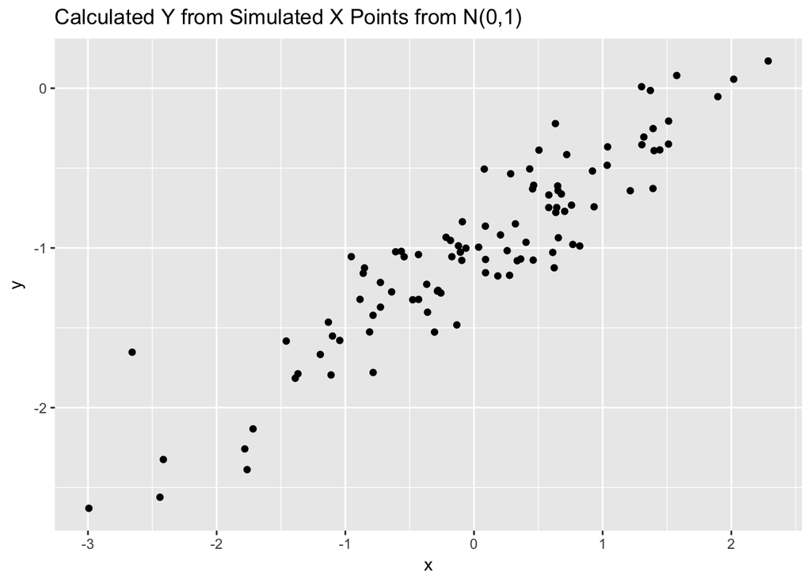

```r
df = data.frame(x,y)
ggplot(data = df, aes(x, y)) +
  geom_point() + ggtitle("Calculated Y from Simulated X Points from N(0,1)")
```

The correlation between $X$ and $Y$ is strong and positive, which makes sense given the equation for $Y$. There does appear to be one or two outliers.

5. Fit a least squares linear model to predict `y` using `x`. Comment on the model obtained. How do $\hat{\beta}_0$ and $\hat{\beta}_1$ compare to $\beta_0$ and $\beta_1$?

```r
model = lm(y~x)
summary(model)
```

```
##
## Call:
## lm(formula = y ~ x)
##
## Residuals:
##      Min       1Q   Median       3Q      Max
## -0.47211 -0.12666  0.00306  0.13527  0.71560
##
## Coefficients:
##             Estimate Std. Error t value Pr(>|t|)
## (Intercept) -1.02209    0.02272  -44.99   <2e-16 ***
## x            0.50679    0.02192   23.12   <2e-16 ***
## ---
## Signif. codes:  0 '***' 0.001 '**' 0.01 '*' 0.05 '.' 0.1 ' ' 1
##
## Residual standard error: 0.2271 on 98 degrees of freedom
## Multiple R-squared:  0.8451, Adjusted R-squared:  0.8435
## F-statistic: 534.7 on 1 and 98 DF,  p-value: < 2.2e-16
```

The model is fairly strong, with an $R^2$ value of $0.84$ and RSE of $0.22$. The calculated $\beta$ values are close to the actual $\beta$ values. Here $\hat{\beta}_0 = -1.02209$ when $\beta_0 = -1$ and $\hat{\beta}_1 = 0.50679$ when $\beta_1 = 0.5$.

6. Display the least squares line on the scatterplot obtained in (d). Draw the population regression line on the plot, in a different color. Use the `legend()` command to create an appropriate legend.

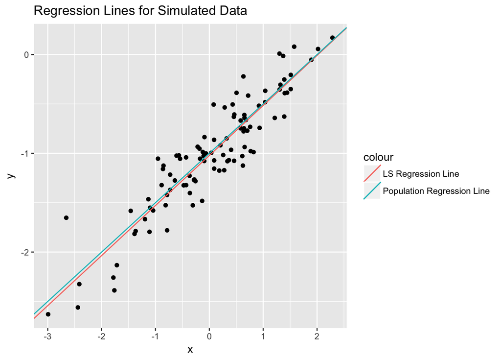

```r
ggplot(df, aes(x,y)) + geom_point() +
  geom_abline(aes(intercept = model$coefficients[1],
                  slope = model$coefficients[2],
                  col = "LS Regression Line")) +
  geom_abline((aes(intercept = -1,
                   slope = 0.5,
                   col = "Population Regression Line"))) +
  ggtitle("Regression Lines for Simulated Data")
```

7. Now fit a polynomial regression model that predicts `y` using `x` and `x^2`. Is there evidence that the quadratic term improves the model fit? Explain your answer.

```r
model2 = lm(data = df, y~x+poly(x,2))
summary(model2)
```

```
##
## Call:
## lm(formula = y ~ x + poly(x, 2), data = df)
##
## Residuals:
##      Min       1Q   Median       3Q      Max
## -0.47440 -0.12491  0.00183  0.13597  0.70686
##
## Coefficients: (1 not defined because of singularities)
##             Estimate Std. Error t value Pr(>|t|)
## (Intercept) -1.02209    0.02283  -44.76   <2e-16 ***
## x            0.50679    0.02203   23.01   <2e-16 ***
## poly(x, 2)1       NA         NA      NA       NA
## poly(x, 2)2  0.02736    0.22823    0.12    0.905
## ---
## Signif. codes:  0 '***' 0.001 '**' 0.01 '*' 0.05 '.' 0.1 ' ' 1
##
## Residual standard error: 0.2282 on 97 degrees of freedom
## Multiple R-squared:  0.8451, Adjusted R-squared:  0.8419
## F-statistic: 264.7 on 2 and 97 DF,  p-value: < 2.2e-16
```

The quadratic term does not appear to improve the model fit, given the low $t$-statistic and high $p$-value. This means that the coefficient is statistically insignificant.

8. Repeat (a)-(f) after modifying the data generative process in such a way that there is *less* noise in the data. The model
   $$Y = -1 + 0.5X + \varepsilon$$
   should remain the same. Do this by decreasing the variance of the normal distrbution used to generate the error term $\varepsilon$ in (b). Describe the results.

```r
x2 = rnorm(100)
eps2 = rnorm(100, 0, 0.1)
y2 = -1 + 0.5*x2 + eps2

df2 = data.frame(x2, y2)
model2 = lm(data = df2, y2~x2)
summary(model2)
```

```
##
## Call:
## lm(formula = y2 ~ x2, data = df2)
##
## Residuals:
##       Min        1Q    Median        3Q       Max
## -0.171606 -0.056497 -0.009962  0.064930  0.242228
##
## Coefficients:
##              Estimate Std. Error t value Pr(>|t|)
## (Intercept) -0.996747   0.008798 -113.30   <2e-16 ***
## x2           0.496039   0.008694   57.06   <2e-16 ***
## ---
## Signif. codes:  0 '***' 0.001 '**' 0.01 '*' 0.05 '.' 0.1 ' ' 1
##
## Residual standard error: 0.08797 on 98 degrees of freedom
## Multiple R-squared:  0.9708, Adjusted R-squared:  0.9705
## F-statistic:  3256 on 1 and 98 DF,  p-value: < 2.2e-16
```

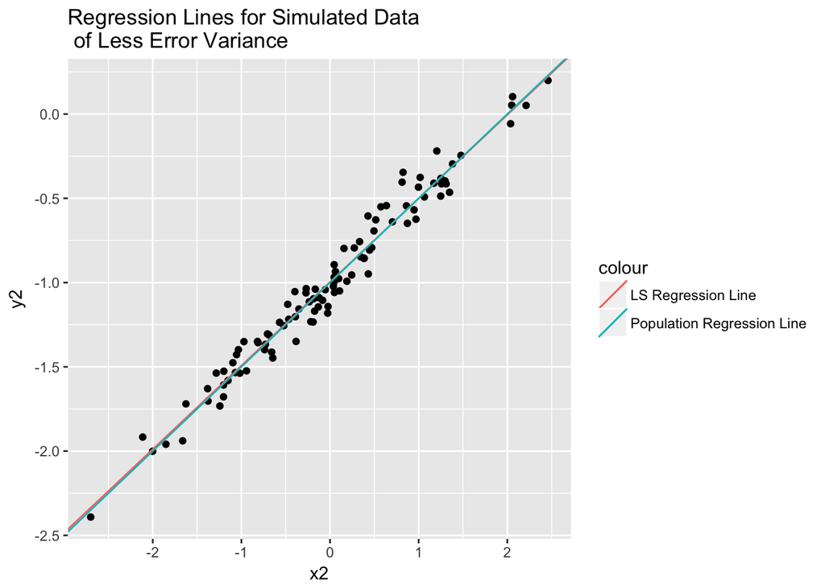

```r
ggplot(df2, aes(x2,y2)) + geom_point() +
  geom_abline(aes(intercept = model2$coefficients[1],
                  slope = model2$coefficients[2],
                  col = "LS Regression Line")) +
  geom_abline((aes(intercept = -1,
                   slope = 0.5,
                   col = "Population Regression Line"))) +
  ggtitle("Regression Lines for Simulated Data \n of Less Error Variance")
```

The least squares regression line comes close to the population regression line when there is less variance in the error. The $\hat{\beta}$ are also really close to its respective $\beta$ values. The residual standard error is lower when there is less error.

1. Repeat (a)-(f) after modifying the data generative process in such a way that there is *more* noise in the data. The model
   $$Y = -1 + 0.5X + \varepsilon$$
   should remain the same. Do this by increasing the variance of the normal distribution used to generate the error term $\varepsilon$ in (b). Describe the results.

```r
x3 = rnorm(100)
eps3 = rnorm(100, 0, 0.75)
y3 = -1 + 0.5*x3 + eps3

df3 = data.frame(x3, y3)
model3 = lm(data = df3, y3~x3)
summary(model3)
```

```
##
## Call:
## lm(formula = y3 ~ x3, data = df3)
##
## Residuals:
##      Min       1Q   Median       3Q      Max
## -1.65795 -0.49400 -0.01423  0.52228  2.30014
##
## Coefficients:
##             Estimate Std. Error t value Pr(>|t|)
## (Intercept) -0.98419    0.07975 -12.341  < 2e-16 ***
## x3           0.61916    0.07806   7.932 3.54e-12 ***
## ---
## Signif. codes:  0 '***' 0.001 '**' 0.01 '*' 0.05 '.' 0.1 ' ' 1
##
## Residual standard error: 0.7922 on 98 degrees of freedom
## Multiple R-squared:  0.391,  Adjusted R-squared:  0.3848
## F-statistic: 62.92 on 1 and 98 DF,  p-value: 3.539e-12
```

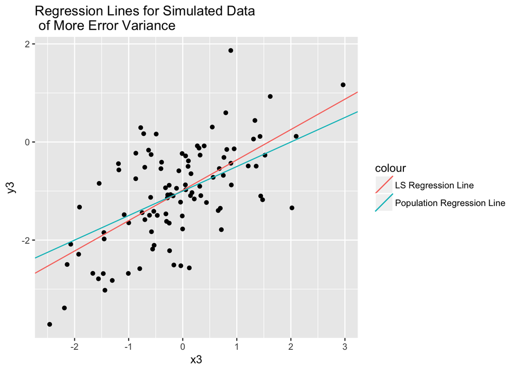

```r
ggplot(df3, aes(x3,y3)) + geom_point() +
  geom_abline(aes(intercept = model3$coefficients[1],
                  slope = model3$coefficients[2],
                  col = "LS Regression Line")) +
  geom_abline((aes(intercept = -1,
                   slope = 0.5,
                   col = "Population Regression Line"))) +
  ggtitle("Regression Lines for Simulated Data \n of More Error Variance")
```

The data stimulated here are more sparse in its distribution and does not have a strong linear relationship as above. The estimated $\hat{\beta}$ are also farther from its actual $\beta$ values than before. The residual standard error is greater than before.

10. What are the confidence intervals for $\beta_0$ and $\beta_1$ based on the original data set? the noisier data set, and the less noisy data set? Comment on the results.

```r
confint(model)
```

```
##                  2.5 %     97.5 %
## (Intercept) -1.0671777 -0.9770057
## x            0.4632977  0.5502819
```

```r
confint(model2)
```

```
##                  2.5 %     97.5 %
## (Intercept) -1.0142062 -0.9792886
## x2           0.4787863  0.5132910
```

```r
confint(model3)
```

```
##                  2.5 %     97.5 %
## (Intercept) -1.1424487 -0.8259252
## x3           0.4642568  0.7740588
```

As the data set gets noisier, there is a greater spread in the confidence interval for both coefficients; this means that the parameter was confidently captured in a larger range. On the other hand, as the data set gets less noisier, there is a smaller spread in the confidence interval for both coefficients; this means there is more confidence that the true parameter was captured in a smaller range.

## Question 14: This problem focuses on the *collinearity* problem.

1. Perform the following commands.

```r
set.seed(25)
x1 = runif(100)
x2 = 0.5*x1 + rnorm(100)/10
y = 2 + 2*x1 + 0.3*x2 + rnorm(100)
```

The last line corresponds to creating a linear model in which `y` is a function of `x1` and `x2`. Write out the form of the linear model. What are the regression coefficient?
$$y = \beta_0 + 2\beta_1 + 0.3\beta_2 + \varepsilon$$
where $\beta_0 = 2$, $\beta_1 = 2$ and $\beta_2 = 0.3$.

2. What is the correlation between `x1` and `x2`? Create a scatterplot displaying the relationship between the variables.

```r
cor(x1,x2)
```

```
## [1] 0.8440404
```

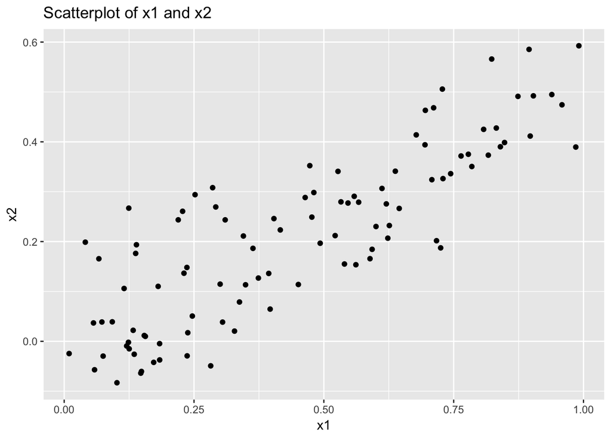

```r
df = data.frame(x1, x2, y)
ggplot(data = df, aes(x1, x2)) + geom_point() + ggtitle("Scatterplot of x1 and x2")
```

3. Using this data, fit a least squares regression to predict `y` using `x1` and `x2`. Describe the results obtained. What are $\hat{\beta}_0$, $\hat{\beta}_1$, and $\hat{\beta}_2$? How do these relate to the true $\beta_0$, $\beta_1$, and $\beta_2$? Can you reject the null hypothesis $H_): \beta_1 = 0$? How about the null hypothesis $H_0: \beta_2 = 0$?

```r
model = lm(data = df, y~x1 + x2)
summary(model)
```

```
##
## Call:
## lm(formula = y ~ x1 + x2, data = df)
##
## Residuals:
##      Min       1Q   Median       3Q      Max
## -2.62782 -0.69419 -0.06898  0.62083  2.34016
##
## Coefficients:
##             Estimate Std. Error t value Pr(>|t|)
## (Intercept)   1.9157     0.1917   9.993   <2e-16 ***
## x1            1.3653     0.6720   2.032   0.0449 *
## x2            2.5851     1.0865   2.379   0.0193 *
## ---
## Signif. codes:  0 '***' 0.001 '**' 0.01 '*' 0.05 '.' 0.1 ' ' 1
##
## Residual standard error: 0.9917 on 97 degrees of freedom
## Multiple R-squared:  0.3915, Adjusted R-squared:  0.379
## F-statistic: 31.21 on 2 and 97 DF,  p-value: 3.436e-11
```

4. Now fit a least squares regression to predict `y` using only `x1`. Comment on the results. Can you reject the null hypothesis $H_0: \beta_1 = 0$?

```r
model2 = lm(data = df, y~x1)
summary(model2)
```

```
##
## Call:
## lm(formula = y ~ x1, data = df)
##
## Residuals:
##      Min       1Q   Median       3Q      Max
## -3.06463 -0.67723 -0.09991  0.70066  2.64774
##
## Coefficients:
##             Estimate Std. Error t value Pr(>|t|)
## (Intercept)   1.8585     0.1947   9.547 1.16e-15 ***
## x1            2.7149     0.3689   7.360 5.72e-11 ***
## ---
## Signif. codes:  0 '***' 0.001 '**' 0.01 '*' 0.05 '.' 0.1 ' ' 1
##
## Residual standard error: 1.015 on 98 degrees of freedom
## Multiple R-squared:  0.356,  Adjusted R-squared:  0.3494
## F-statistic: 54.17 on 1 and 98 DF,  p-value: 5.719e-11
```

The model does slightly worse here when removing one of the two predictor variables. The RSE went slightly up while the $R^2$ value went slightly down. The null hypothesis can be rejected here.

5. Now fit a least squares regression to predict `y` using only `x2`. Comment on the results. Can you reject the null hypothesis $H_0: \beta_1 = 0$?

```r
model3 = lm(data = df, y~x2)
summary(model3)
```

```
##
## Call:
## lm(formula = y ~ x2, data = df)
##
## Residuals:
##      Min       1Q   Median       3Q      Max
## -2.20520 -0.67113 -0.05196  0.79059  2.29363
##
## Coefficients:
##             Estimate Std. Error t value Pr(>|t|)
## (Intercept)   2.1337     0.1614  13.222  < 2e-16 ***
## x2            4.4483     0.5919   7.515  2.7e-11 ***
## ---
## Signif. codes:  0 '***' 0.001 '**' 0.01 '*' 0.05 '.' 0.1 ' ' 1
##
## Residual standard error: 1.007 on 98 degrees of freedom
## Multiple R-squared:  0.3656, Adjusted R-squared:  0.3591
## F-statistic: 56.48 on 1 and 98 DF,  p-value: 2.701e-11
```

The same results can be drawn here as above. The model does slightly worse when removing the other predictor variable. The RSE went slightly up while the $R^2$ value went slightly down. The null hypothesis can also be rejected here.

6. Do the results obtained in (c)-(e) contradict each other? Explain your answer.

The results in (c)-(e) do contradict each other. When `x1` and `x2` are used together in the linear model, it predicts the model well while showing that the coefficient estimates are not statistically significant at the $\alpha$ level of $0.01$. On other hand, when `x1` and `x2` are individually used to create the linear model, it predicts the model poorly but show that the coefficient estimates are statistically significant.

7. Now suppose there is one additional observation, which was unfortunately mismeasured.

```r
x1 = c(x1, 0.1)
x2 = c(x2, 0.8)
y = c(y, 6)
```

Re-fit the linear models from (c) to (e) using this new data. What effect does this new observation have on each of the models? In each model, is this observation an outlier? A high leverage point? Both? Explain your answer.

```r
df2 = data.frame(x1, x2, y)

model_new1 = lm(data = df2, y~x1+x2)
model_new2 = lm(data = df2, y~x1)
model_new3 = lm(data = df2, y~x2)

summary(model_new1)
```

```
##
## Call:
## lm(formula = y ~ x1 + x2, data = df2)
##
## Residuals:
##      Min       1Q   Median       3Q      Max
## -2.45599 -0.73212 -0.02505  0.69838  2.22347
##
## Coefficients:
##             Estimate Std. Error t value Pr(>|t|)
## (Intercept)   1.9711     0.1888  10.440  < 2e-16 ***
## x1            0.7934     0.5446   1.457    0.148
## x2            3.5848     0.8395   4.270 4.52e-05 ***
## ---
## Signif. codes:  0 '***' 0.001 '**' 0.01 '*' 0.05 '.' 0.1 ' ' 1
##
## Residual standard error: 0.9971 on 98 degrees of freedom
## Multiple R-squared:  0.4103, Adjusted R-squared:  0.3982
## F-statistic: 34.09 on 2 and 98 DF,  p-value: 5.778e-12
```

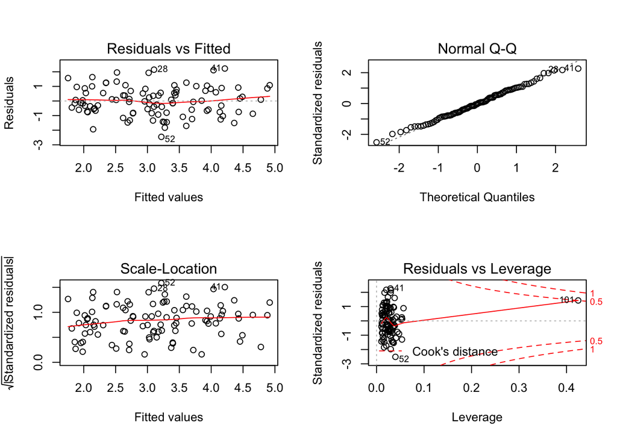

```r
par(mfrow=c(2,2))
plot(model_new1)
```

```r
summary(model_new2)
```

```
##
## Call:
## lm(formula = y ~ x1, data = df2)
##
## Residuals:
##     Min      1Q  Median      3Q     Max
## -3.0544 -0.6883 -0.0933  0.6919  3.7711
##
## Coefficients:
##             Estimate Std. Error t value Pr(>|t|)
## (Intercept)   1.9748     0.2046   9.653 6.26e-16 ***
## x1            2.5404     0.3895   6.522 2.95e-09 ***
## ---
## Signif. codes:  0 '***' 0.001 '**' 0.01 '*' 0.05 '.' 0.1 ' ' 1
##
## Residual standard error: 1.08 on 99 degrees of freedom
## Multiple R-squared:  0.3005, Adjusted R-squared:  0.2935
## F-statistic: 42.54 on 1 and 99 DF,  p-value: 2.952e-09
```

```r
par(mfrow=c(2,2))
plot(model_new2)

summary(model_new3)
```

[output not shown]

```
##
## Call:
## lm(formula = y ~ x2, data = df2)
##
## Residuals:
##      Min       1Q   Median       3Q      Max
## -2.20651 -0.67070 -0.04967  0.78643  2.29248
##
## Coefficients:
##             Estimate Std. Error t value Pr(>|t|)
## (Intercept)   2.1247     0.1575  13.486  < 2e-16 ***
## x2            4.5035     0.5572   8.082  1.6e-12 ***
## ---
## Signif. codes:  0 '***' 0.001 '**' 0.01 '*' 0.05 '.' 0.1 ' ' 1
##
## Residual standard error: 1.003 on 99 degrees of freedom
## Multiple R-squared:  0.3975, Adjusted R-squared:  0.3914
## F-statistic: 65.32 on 1 and 99 DF,  p-value: 1.602e-12
```

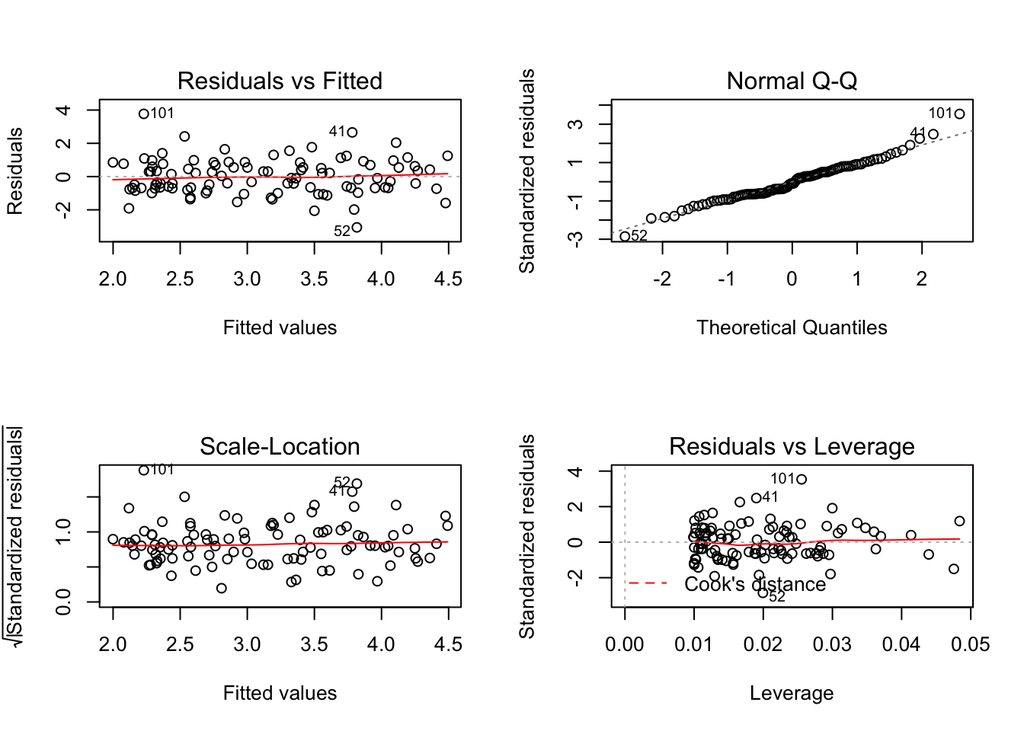

```r
par(mfrow=c(2,2))
plot(model_new2)
```

## Question 15: This problem involves the `Boston` data set. We will now try to predict per capita crime rate using the other variables in this data set. In other words, per capita crime rate is the response and the other variables are the predictors.

1. For each predictor, fit a simple linear regression model to predict the response. Describe your results. In which of the models is there is a statistically significant association between the predictor and the predictor?

```r
df = Boston
model1 = lm(data = df, crim~zn)
model2 = lm(data = df, crim~indus)
model3 = lm(data = df, crim~chas)
model4 = lm(data = df, crim~nox)
model5 = lm(data = df, crim~rm)
model6 = lm(data = df, crim~age)
model7 = lm(data = df, crim~dis)
model8 = lm(data = df, crim~rad)
model9 = lm(data = df, crim~tax)
model10 = lm(data = df, crim~ptratio)
model11 = lm(data = df, crim~black)
model12 = lm(data = df, crim~lstat)
model13 = lm(data = df, crim~medv)

summary(model1)$coefficients[2,4]
```

```
## [1] 5.506472e-06
```

```r
summary(model2)$coefficients[2,4]
```

```
## [1] 1.450349e-21
```

```r
summary(model3)$coefficients[2,4]
```

```
## [1] 0.2094345
```

```r
summary(model4)$coefficients[2,4]
```

```
## [1] 3.751739e-23
```

```r
summary(model5)$coefficients[2,4]
```

```
## [1] 6.346703e-07
```

```r
summary(model6)$coefficients[2,4]
```

```
## [1] 2.854869e-16
```

```r
summary(model7)$coefficients[2,4]
```

```
## [1] 8.519949e-19
```

```r
summary(model8)$coefficients[2,4]
```

```
## [1] 2.693844e-56
```

```r
summary(model9)$coefficients[2,4]
```

```
## [1] 2.357127e-47
```

```r
summary(model10)$coefficients[2,4]
```

```
## [1] 2.942922e-11
```

```r
summary(model11)$coefficients[2,4]
```

```
## [1] 2.487274e-19
```

```r
summary(model12)$coefficients[2,4]
```

```
## [1] 2.654277e-27
```

```r
summary(model13)$coefficients[2,4]
```

```
## [1] 1.173987e-19
```

All of the coefficient estimates are statistically significant at the $\alpha$ level of $0.01$ except `chas`.

2. Fit a multiple regression model to predict the response using all of the predictors. Describe your results. For which predictors can we reject the null hypothesis $H_0: \beta_j = 0$?

```r
model = lm(data = df, crim~.)
summary(model)
```

```
##
## Call:
## lm(formula = crim ~ ., data = df)
##
## Residuals:
##    Min     1Q Median     3Q    Max
## -9.924 -2.120 -0.353  1.019 75.051
##
## Coefficients:
##               Estimate Std. Error t value Pr(>|t|)
## (Intercept)  17.033228   7.234903   2.354 0.018949 *
## zn            0.044855   0.018734   2.394 0.017025 *
## indus        -0.063855   0.083407  -0.766 0.444294
## chas         -0.749134   1.180147  -0.635 0.525867
## nox         -10.313535   5.275536  -1.955 0.051152 .
## rm            0.430131   0.612830   0.702 0.483089
## age           0.001452   0.017925   0.081 0.935488
## dis          -0.987176   0.281817  -3.503 0.000502 ***
## rad           0.588209   0.088049   6.680 6.46e-11 ***
## tax          -0.003780   0.005156  -0.733 0.463793
## ptratio      -0.271081   0.186450  -1.454 0.146611
## black        -0.007538   0.003673  -2.052 0.040702 *
## lstat         0.126211   0.075725   1.667 0.096208 .
## medv         -0.198887   0.060516  -3.287 0.001087 **
## ---
## Signif. codes:  0 '***' 0.001 '**' 0.01 '*' 0.05 '.' 0.1 ' ' 1
##
## Residual standard error: 6.439 on 492 degrees of freedom
## Multiple R-squared:  0.454,  Adjusted R-squared:  0.4396
## F-statistic: 31.47 on 13 and 492 DF,  p-value: < 2.2e-16
```

The model has a RSE value of $6.439$ and $R^2$ value of $0.454$. The coefficient estimates that are statistically significant are `dis`, `rad`, and `medv` and thus their null hypotheses can be rejected.

3. How do your results from (a) compare to your results from (b)? Create a plot displaying the univariate regression coefficients from (a) on the $x$-axis, and the multiple regression coefficients from (b) on the $y$-axis. That is, each predictor is displayed as a single point in the plot. Its coefficient in a simple linear regression model is shown on the $x$-axis and its coefficient estimate in the multiple linear regression model is shown on the $y$-axis.

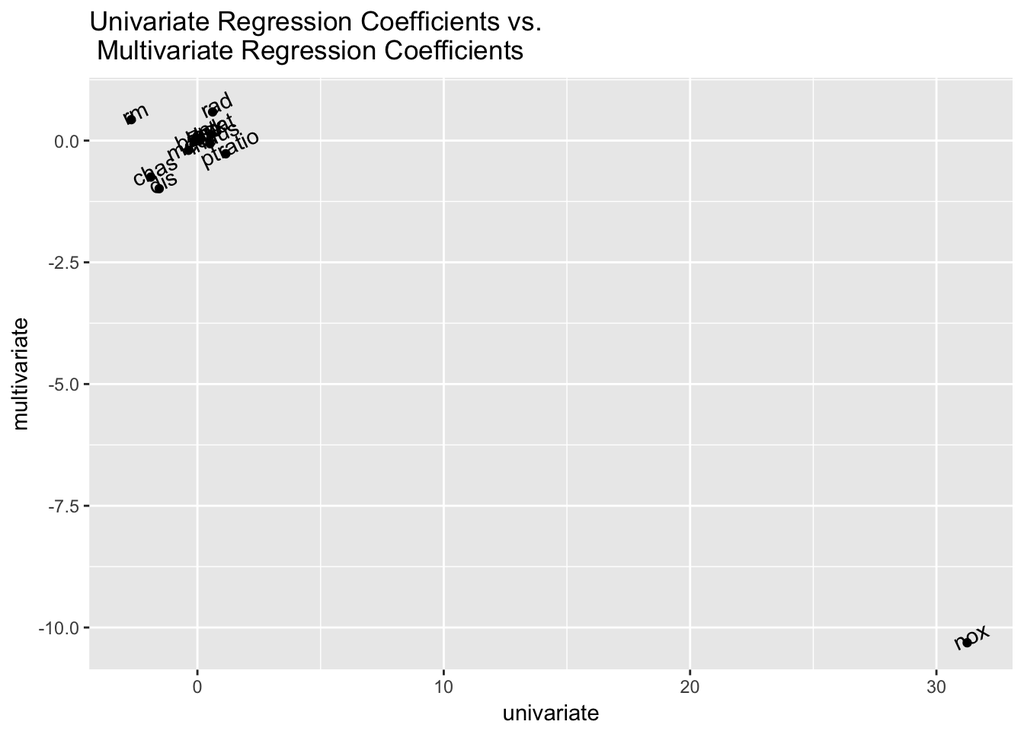

```r
univariate_coeffs = c(summary(model1)$coefficients[2,1], summary(model2)$coefficients[2,1],
                      summary(model3)$coefficients[2,1], summary(model4)$coefficients[2,1],
                      summary(model5)$coefficients[2,1], summary(model6)$coefficients[2,1],
                      summary(model7)$coefficients[2,1], summary(model8)$coefficients[2,1],
                      summary(model9)$coefficients[2,1], summary(model10)$coefficients[2,1],
                      summary(model11)$coefficients[2,1], summary(model12)$coefficients[2,1],
                      summary(model13)$coefficients[2,1])
multivariate_coeffs = summary(model)$coefficients[2:14,1]
coeffs = data.frame(univariate = univariate_coeffs, multivariate = multivariate_coeffs)

ggplot(data = coeffs, aes(x = univariate, y = multivariate, label = rownames(coeffs))) + geom_point() +
  ggtitle("Univariate Regression Coefficients vs. \n Multivariate Regression Coefficients") +
  geom_text(vjust = 0.5, nudge_x = 0.15, nudge_y = 0.15, angle = 25) #+ xlim(-3,2) + ylim(-1.5, 1)
```

The predictor `nox` had a vastly different coefficient estimate between the univariate regression and the multivariate regression. Omit this point to look at the other predictors in a closer view.

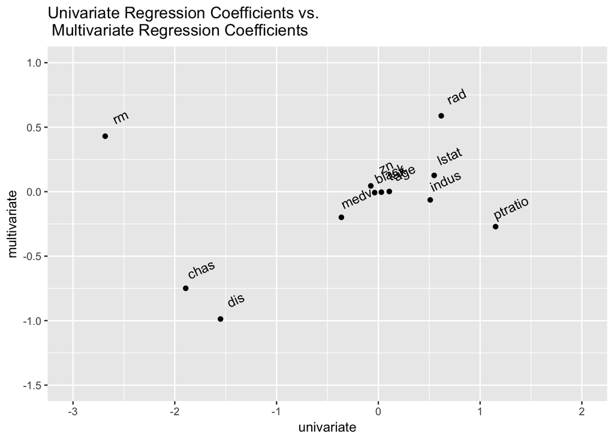

```r
ggplot(data = coeffs, aes(x = univariate, y = multivariate, label = rownames(coeffs))) + geom_point() +
  ggtitle("Univariate Regression Coefficients vs. \n Multivariate Regression Coefficients") +
  geom_text(vjust = 0.5, nudge_x = 0.15, nudge_y = 0.15, angle = 25) + xlim(-3,2) + ylim(-1.5, 1)
```

4. Is there evidence of non-linear association between any of the predictors and the response? To answer this question, for each predictor $X$, fit a model of the form
   $$Y = \beta_0 + \beta_1X + \beta_2X^2 + \beta_3X^3 + \varepsilon$$

```r
summary(lm(data = df, crim~poly(zn,3)))$coefficients[,4]
```

```
##  (Intercept) poly(zn, 3)1 poly(zn, 3)2 poly(zn, 3)3
## 1.547150e-20 4.697806e-06 4.420507e-03 2.295386e-01
```

```r
summary(lm(data = df, crim~poly(indus,3)))$coefficients[,4]
```

```
##     (Intercept) poly(indus, 3)1 poly(indus, 3)2 poly(indus, 3)3
##    3.606468e-25    8.854243e-24    1.086057e-03    1.196405e-12
```

```r
#summary(lm(data = df, crim~poly(chas,3)))$coefficients[,4]
summary(lm(data = df, crim~poly(nox,3)))$coefficients[,4]
```

```
##   (Intercept) poly(nox, 3)1 poly(nox, 3)2 poly(nox, 3)3
##  2.742908e-26  2.457491e-26  7.736755e-05  6.961110e-16
```

```r
summary(lm(data = df, crim~poly(rm,3)))$coefficients[,4]
```

```
##  (Intercept) poly(rm, 3)1 poly(rm, 3)2 poly(rm, 3)3
## 1.026665e-20 5.128048e-07 1.508545e-03 5.085751e-01
```

```r
summary(lm(data = df, crim~poly(age,3)))$coefficients[,4]
```

```
##   (Intercept) poly(age, 3)1 poly(age, 3)2 poly(age, 3)3
##  5.918933e-23  4.878803e-17  2.291156e-06  6.679915e-03
```

```r
summary(lm(data = df, crim~poly(dis,3)))$coefficients[,4]
```

```
##   (Intercept) poly(dis, 3)1 poly(dis, 3)2 poly(dis, 3)3
##  1.060226e-25  1.253249e-21  7.869767e-14  1.088832e-08
```

```r
summary(lm(data = df, crim~poly(rad)))$coefficients[,4]
```

```
##  (Intercept)    poly(rad)
## 9.143174e-30 2.693844e-56
```

```r
summary(lm(data = df, crim~poly(tax,3)))$coefficients[,4]
```

```
##   (Intercept) poly(tax, 3)1 poly(tax, 3)2 poly(tax, 3)3
##  8.955923e-29  6.976314e-49  3.665348e-06  2.438507e-01
```

```r
summary(lm(data = df, crim~poly(ptratio,3)))$coefficients[,4]
```

```
##       (Intercept) poly(ptratio, 3)1 poly(ptratio, 3)2 poly(ptratio, 3)3
##      1.270767e-21      1.565484e-11      2.405468e-03      6.300514e-03
```

```r
summary(lm(data = df, crim~poly(black,3)))$coefficients[,4]
```

```
##     (Intercept) poly(black, 3)1 poly(black, 3)2 poly(black, 3)3
##    2.139710e-22    2.730082e-19    4.566044e-01    5.436172e-01
```

```r
summary(lm(data = df, crim~poly(lstat,3)))$coefficients[,4]
```

```
##     (Intercept) poly(lstat, 3)1 poly(lstat, 3)2 poly(lstat, 3)3
##    4.939398e-24    1.678072e-27    3.780418e-02    1.298906e-01
```

```r
summary(lm(data = df, crim~poly(medv,3)))$coefficients[,4]
```

```
##    (Intercept) poly(medv, 3)1 poly(medv, 3)2 poly(medv, 3)3
##   7.024110e-31   4.930818e-27   2.928577e-35   1.046510e-12
```

There is non-linear association between the response and

- `zn`, of degree $1$ and $2$
- `indus`, of degree $1$, $2$ and $3$
- `nox`, of degree $1$, $2$ and $3$
- `rm`, of degree $1$ and $2$
- `age`, of degree $1$, $2$ and $3$
- `dis`, of degree $1$, $2$ and $3$
- `rad`, of degree $1$
- `tax`, of degree $1$ and $2$
- `ptratio`, of degree $1$, $2$ and $3$
- `black`, of degree $1$
- `lstat`, of degree $1$ and $2$
- `medv`, of degree $1$, $2$ and $3$

Note: `chas` cannot be put into polynomial form since it is a factor.

All of the practice applied exercises in this document are taken from “An Introduction to Statistical Learning, with applications in R” (Springer, 2013) with permission from the authors: G. James, D. Witten, T. Hastie and R. Tibshirani.